# Squid

Author

cslovas

## Distributions

### Average biomass and center of biomass based on NEFSC bottom trawl survey

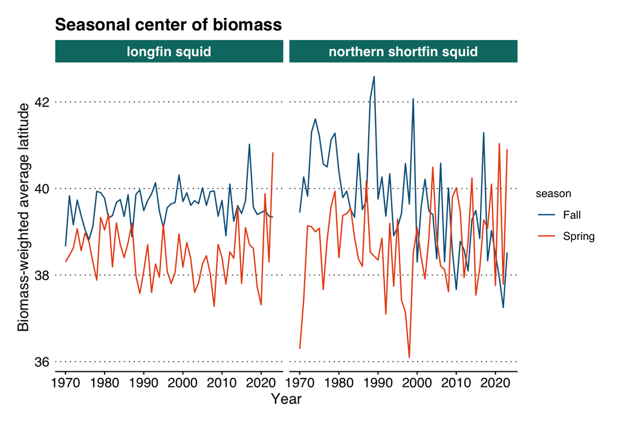

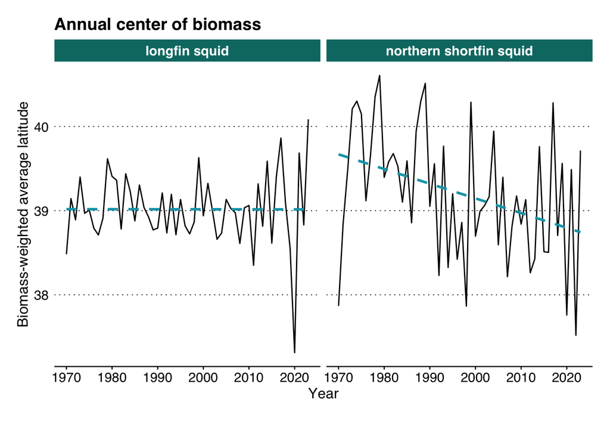

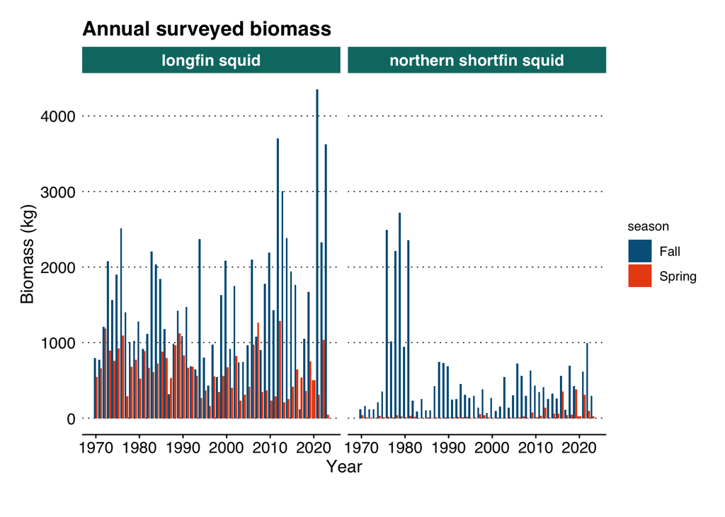

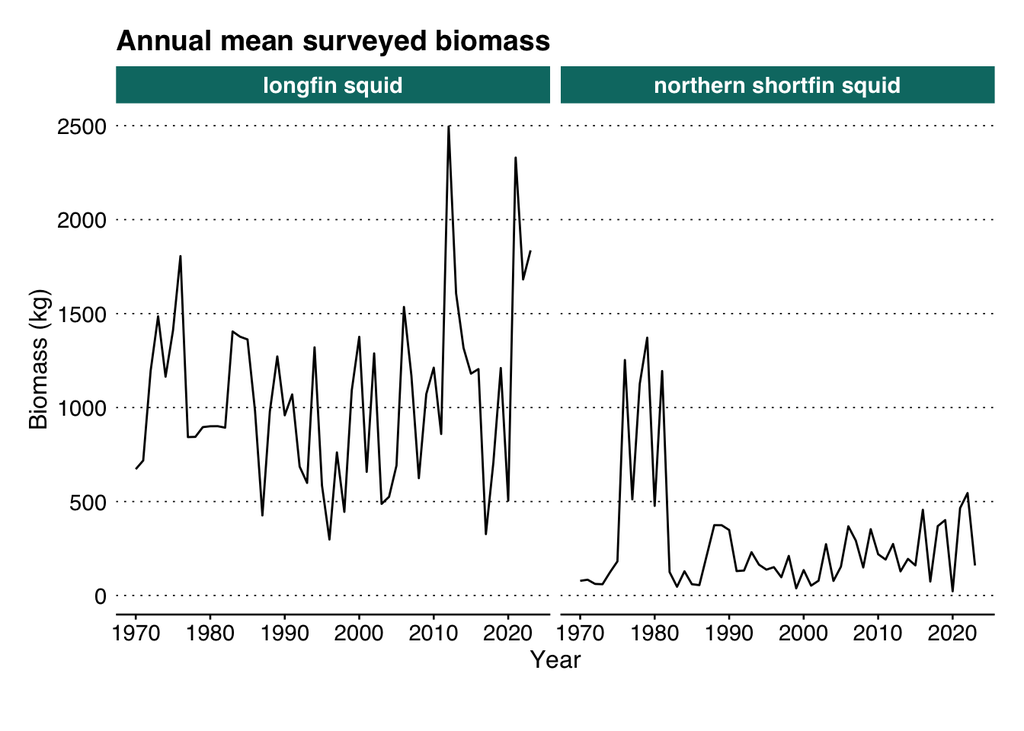

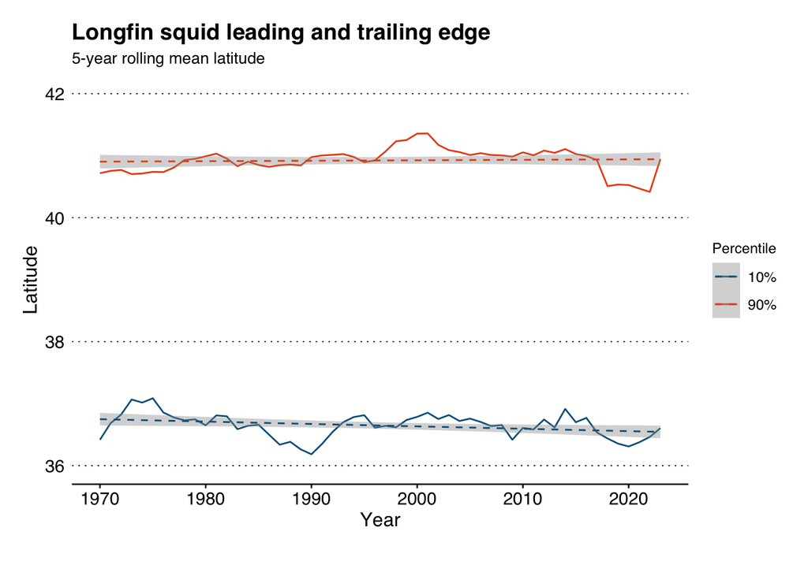

## Landings

### Federally reported landings

Dealer data provided by Greater Atlantic Regional Fisheries Office

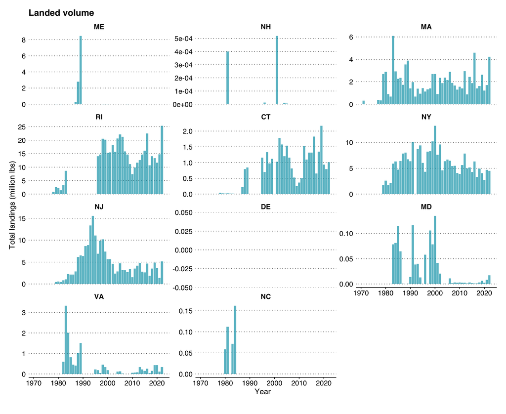

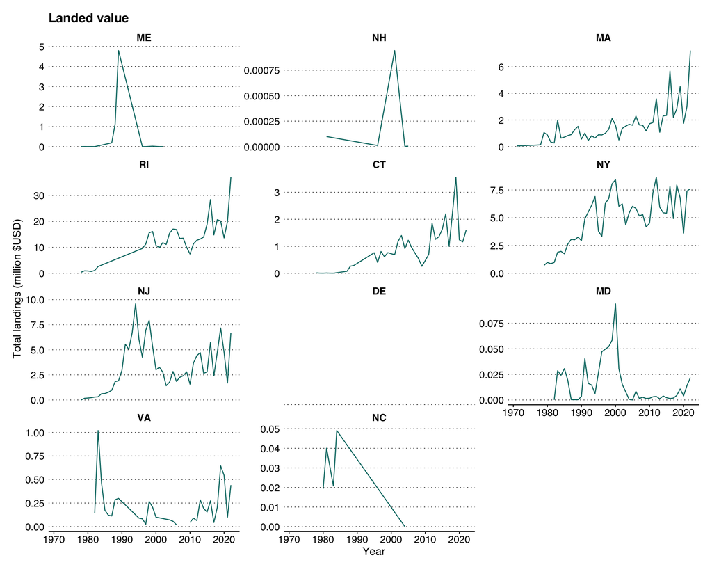

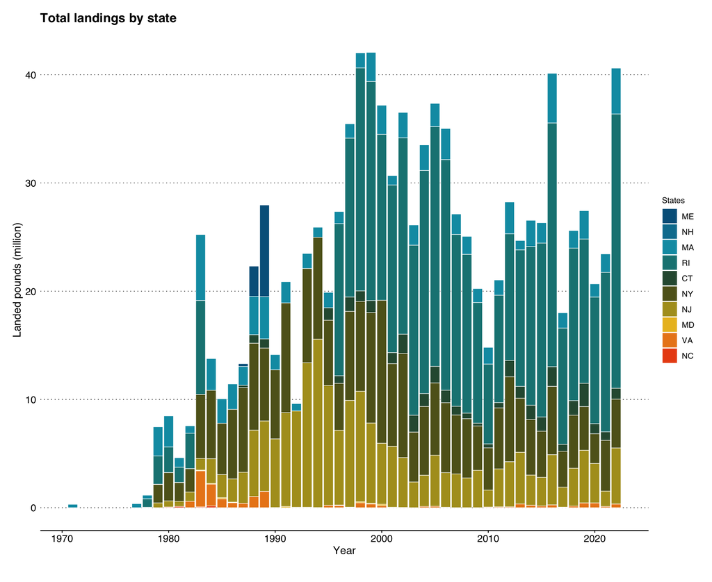

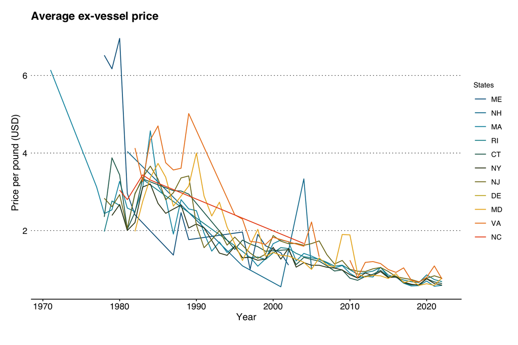

## Licensing

### Federal Licenses

Squid are managed under on fishery management plan (FMP) with mackerel and butterfish and are co-licensed with the same species.

- **Category 1A-C**: Limited access longfin squid (moratorium)
- **Category 2**: Squid/Mackerel/Butterfish Charter Party
- **Category 3**: Squid/Butterfish Incidental Catch
- **Category 4**: Atlantic Mackerel
- **Category 5**: Limited access Illex squid (moratorium)
- **Category 6**: Limited access butterfish (moratorium)
- **Category T1-3**: Limited access mackerel (tier 1-3)

Again, given the focus on longfin squid, we will focus only on *Category 1A-C*, *Category 3*, and *Category 5* licenses.

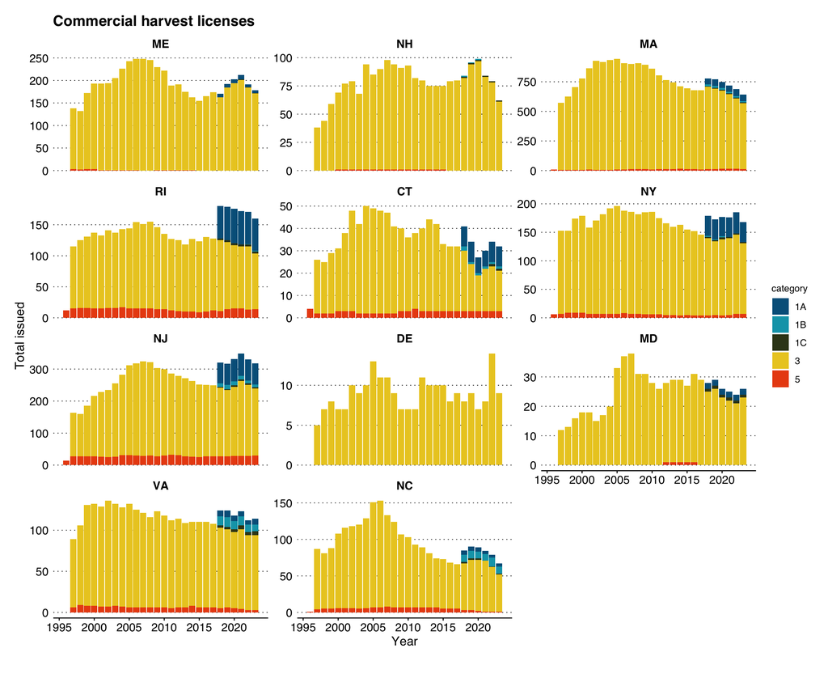

It seems the majority of license types targeting squid are incidental catch.